# ps5 rmarkdown plot

william eng

2023-02-19

```r
gapminder %>%
  sample_n(10)
```

```
## # A tibble: 10 × 25
##    iso3  name         iso2  region sub-r…¹ inter…²  time total…³ ferti…⁴ lifeE…⁵
##    <chr> <chr>        <chr> <chr>  <chr>   <chr>   <dbl>   <dbl>   <dbl>   <dbl>
##  1 MDV   Maldives     MV    Asia   Southe… <NA>     1978  1.49e5    6.96    51.1
##  2 SMR   San Marino   SM    Europe Southe… <NA>     1962  1.63e4   NA       NA
##  3 QAT   Qatar        QA    Asia   Wester… <NA>     1964  6.76e4    6.99    64.1
##  4 IRN   Iran (Islam… IR    Asia   Southe… <NA>     1995  6.14e7    2.94    68.4
##  5 UZB   Uzbekistan   UZ    Asia   Centra… <NA>     1980  1.59e7    5.11    64.6
##  6 SVK   Slovakia     SK    Europe Easter… <NA>     2010  5.39e6    1.43    75.1
##  7 NAM   Namibia      <NA>  Africa Sub-Sa… Southe…  1984  1.16e6    6.03    58.9
##  8 KNA   Saint Kitts… KN    Ameri… Latin … Caribb…  2015  5.12e4   NA       NA
##  9 CYM   Cayman Isla… KY    Ameri… Latin … Caribb…  2010  5.67e4   NA       82.2
## 10 STP   Sao Tome an… ST    Africa Sub-Sa… Middle…  2015  1.99e5    4.48    69.4
## # … with 15 more variables: childMortality <dbl>, youthFemaleLiteracy <dbl>,
## #   youthMaleLiteracy <dbl>, adultLiteracy <dbl>, GDP_PC <dbl>,
## #   accessElectricity <dbl>, agriculturalLand <dbl>, agricultureTractors <dbl>,
## #   cerealProduction <dbl>, fertilizerHa <dbl>, co2 <dbl>,
## #   greenhouseGases <dbl>, co2_PC <dbl>, pm2.5_35 <dbl>, battleDeaths <dbl>,
## #   and abbreviated variable names ¹`sub-region`, ²`intermediate-region`,
## #   ³totalPopulation, ⁴fertilityRate, ⁵lifeExpectancy
```

3. The data looks alright, a lot of missing information in the intermediate-region column. There is also very little information of literacy rates, battle deaths, and access to electricity!
4. There are 250 distinct country names, 249 distinct 2-letter country codes, and 253distinct 3-letter country codes.

```r
gapminder %>%
  group_by(iso2) %>%
  summarise(multiple_names = n_distinct(name)) %>%
  filter(multiple_names > 1)
```

```
## # A tibble: 1 × 2
##   iso2  multiple_names
##   <chr>          <int>
## 1 <NA>               2
```

2a. The reason why there are more country names than 2-letter country codes is because there is an NA value for a country’s iso2 in the data set.

```r
gapminder %>%
  group_by(name) %>%
  summarise(multiple_iso3 = n_distinct(iso3)) %>%
  filter(multiple_iso3 > 1)
```

```
## # A tibble: 1 × 2
##   name  multiple_iso3
##   <chr>         <int>
## 1 <NA>              4
```

2b. The reason why there are more 3-letter country codes than country names is because there are NA values as the names for multiple iso3 values in the data set. No countries have more than one iso3 code, but several iso3 codes do not have a documented country name.

3. The minimum year in the data set is 1960. The maximum year in the data set is 2019.

```r
top_missing_co2 <- gapminder %>%
  group_by(time) %>%
  summarise(NA_co2 = sum(is.na(co2)), NA_co2_PC = sum(is.na(co2_PC))) %>%
  arrange(-NA_co2, -NA_co2_PC) %>%
  head(5)
```

1. 2017, 2018, 2019 have most missing data in co2 and co2_PC.

```r
countries <- c("United States of America", "China", "India", "Aruba", "Canada")

co2em <- gapminder %>%
  filter(name %in% countries) %>%
  group_by(name, time) %>%
  summarise(co2em_countries = sum(co2, na.rm = TRUE))
```

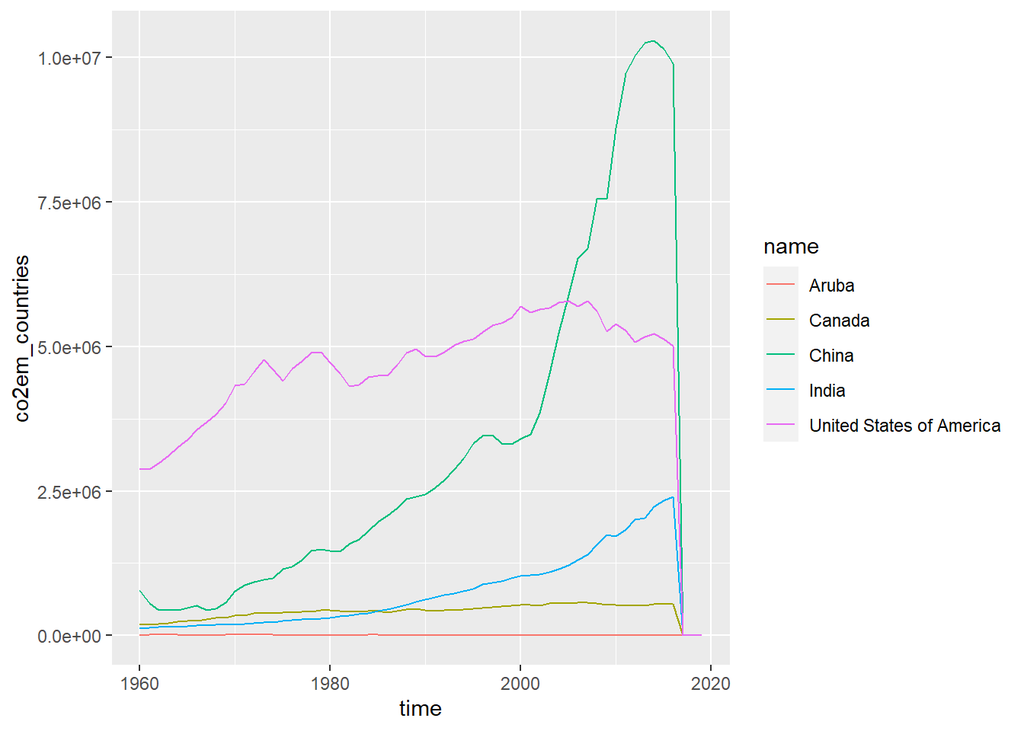

```r
ggplot(co2em, aes(time, co2em_countries, color = name)) +
    geom_line()
```

2. Looking at the plot of total CO2 emissions over time for the US, China, India, Aruba, and Canada, we can observe a sharp decline in emissions in the years preceding 2020.

```r
countries <- c("United States of America", "China", "India", "Aruba", "Canada")

co2emPC <- gapminder %>%
  filter(name %in% countries) %>%
  group_by(name, time) %>%
  summarise(co2em_countries_PC = sum(co2_PC, na.rm = TRUE))
```

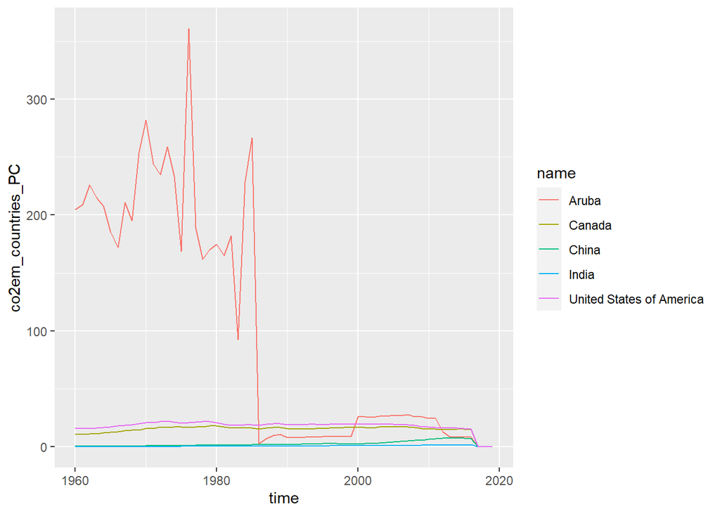

```r
ggplot(co2emPC, aes(time, co2em_countries_PC, color = name)) +
  geom_line()
```

3. Looking at the plot of CO2 emissions per capita over time for the same countries as above, we observe that Aruba has an abnormally high CO2 emission level per capita before the mid-1980’s, which declined sharply to match the other countries after the mid-1980’s. Emissions fell further for all countries just before 2020.

```r
gapminder %>%
  group_by(region) %>%
  filter(time == 2016) %>%
  summarise(avg_co2PC = mean(co2_PC, na.rm = TRUE))
```

```
## # A tibble: 6 × 2
##   region   avg_co2PC
##   <chr>        <dbl>
## 1 Africa        1.20
## 2 Americas      4.80
## 3 Asia          6.47
## 4 Europe        6.64
## 5 Oceania       4.57
## 6 <NA>         19.4
```

```r
co2emPC_continents <- gapminder %>%
  filter(!is.na(region) & time%in%c(1960,2016)) %>%
  group_by(region,time) %>%
  summarize(mean_co2pc = mean(co2_PC, na.rm=TRUE))
```

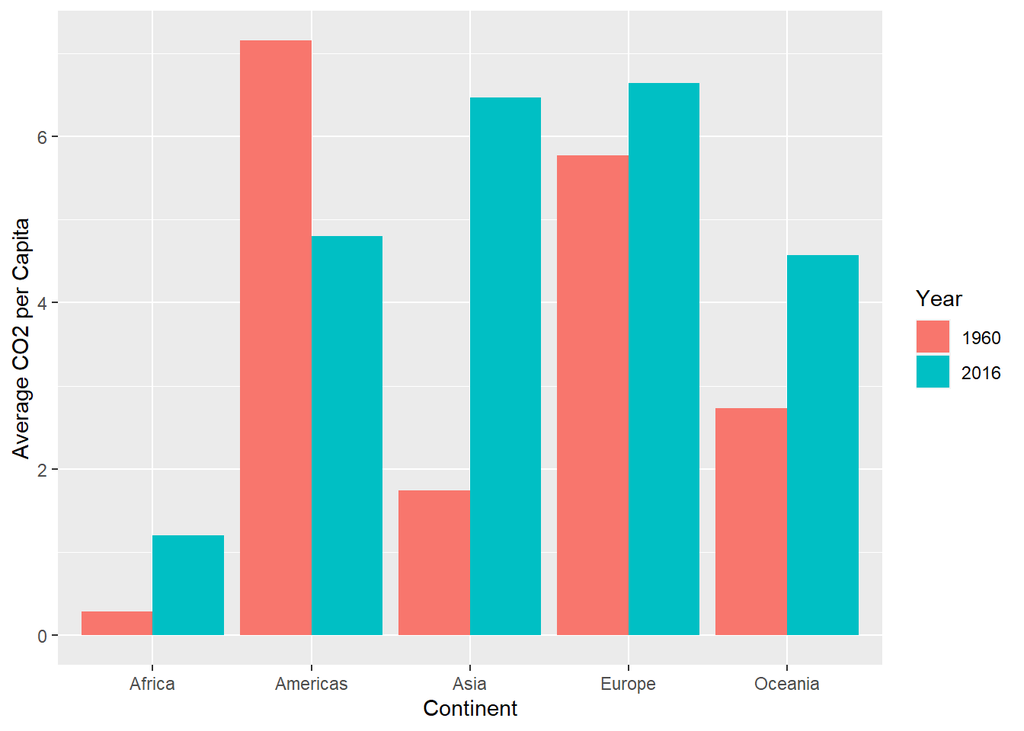

```r
ggplot(co2emPC_continents, aes(region,mean_co2pc,fill=factor(time)))+
  geom_bar(stat='identity', position='dodge')+
  labs(x="Continent",y="Average CO2 per Capita",fill="Year")
```

5. Above is a dodged barplot representing the average CO2 emissions per capita across continents in 1960 and 2016.

```r
gapminder %>%
  filter(!is.na(region) & time==2016) %>%
  select(region, name, co2_PC) %>%
  group_by(region) %>%
  top_n(3, co2_PC) %>%
  arrange(region, desc(co2_PC))
```

```
## # A tibble: 15 × 3
## # Groups:   region [5]
##    region   name                     co2_PC
##    <chr>    <chr>                     <dbl>
##  1 Africa   South Africa               8.48
##  2 Africa   Libya                      7.79
##  3 Africa   Seychelles                 6.39
##  4 Americas Trinidad and Tobago       31.8
##  5 Americas United States of America  15.5
##  6 Americas Canada                    15.1
##  7 Asia     Qatar                     38.9
##  8 Asia     Kuwait                    25.0
##  9 Asia     Bahrain                   22.2
## 10 Europe   Gibraltar                 18.8
## 11 Europe   Luxembourg                15.4
## 12 Europe   Faroe Islands             13.1
## 13 Oceania  New Caledonia             19.3
## 14 Oceania  Australia                 15.5
## 15 Oceania  Palau                     12.6
```

6. Above are the three largest CO2 emitters in each continent.

```r
gapminder %>%
  filter(!is.na(region) & time==2016) %>%
  select(region, name, co2_PC) %>%
  group_by(region) %>%
  top_n(-3, co2_PC) %>%
  arrange(region, co2_PC)
```

```
## # A tibble: 15 × 3
## # Groups:   region [5]
##    region   name                              co2_PC
##    <chr>    <chr>                              <dbl>
##  1 Africa   Congo, Democratic Republic of the 0.0256
##  2 Africa   Somalia                           0.0455
##  3 Africa   Burundi                           0.0472
##  4 Americas Haiti                             0.275
##  5 Americas Nicaragua                         0.887
##  6 Americas Honduras                          1.06
##  7 Asia     Afghanistan                       0.245
##  8 Asia     Nepal                             0.334
##  9 Asia     Yemen                             0.390
## 10 Europe   Liechtenstein                     1.36
## 11 Europe   Albania                           1.58
## 12 Europe   Moldova, Republic of              1.83
## 13 Oceania  Solomon Islands                   0.272
## 14 Oceania  Vanuatu                           0.527
## 15 Oceania  Kiribati                          0.587
```

6. Above are the three smallest CO2 emitters in each continent.

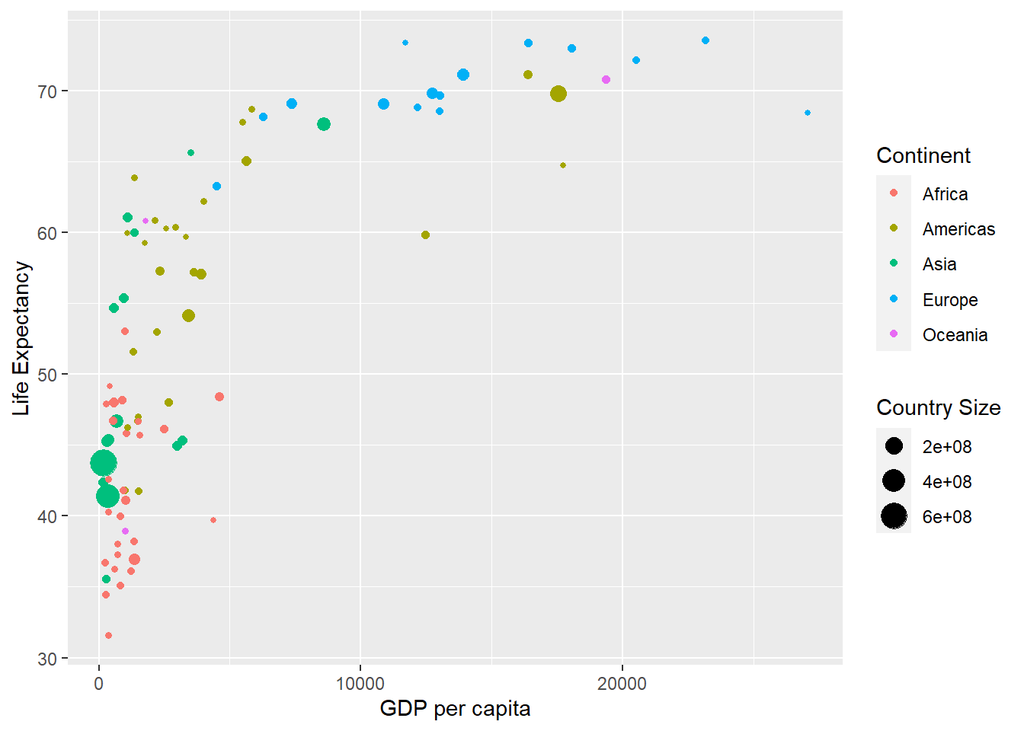

```r
GDP_V_LE <- gapminder %>%
  filter(time == 1960 & !is.na(region) & !is.na(GDP_PC) & !is.na(lifeExpectancy))

ggplot(GDP_V_LE, aes(GDP_PC, lifeExpectancy, col = factor(region)))+
  geom_point(aes(size = totalPopulation))+
  labs(x = "GDP per capita", y = "Life Expectancy", col = "Continent", size = "Country Size")
```

1. The graph above has a positive relationship between GDP/capital and LE. However, despite similar levels of GDP/capita, many countries have very varying life expectancies! European counties tend to have high GDP/capita and high LE, and African countries tend to be the opposite.

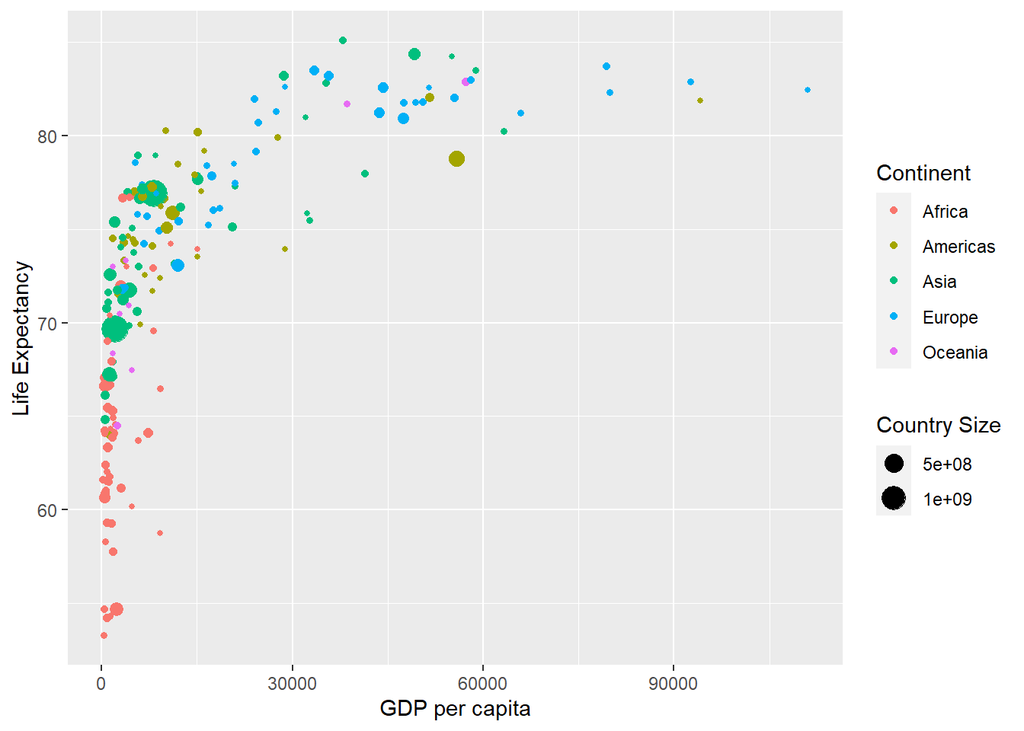

```r
GDP_V_LE <- gapminder %>%
  filter(time == 2019 & !is.na(region) & !is.na(GDP_PC) & !is.na(lifeExpectancy))

ggplot(GDP_V_LE, aes(GDP_PC, lifeExpectancy, col = factor(region))) +
  geom_point(aes(size = totalPopulation)) +
  labs(x = "GDP per capita", y = "Life Expectancy", col = "Continent", size = "Country Size")
```

2. Above is the plot but for 2019 data.

3. Similar observations even after almost 60 years, but almost all countries saw a growth in their LE and GDP/capita. Asian and African countries had the highest growth over the years- compared to European countries, which stagnated somewhat. Africa continues to have relatively low LE.

```r
gapminder %>%
  filter(!is.na(region) & time %in% c(1960,2016)) %>%
  group_by(region, time) %>%
  summarize(ave_LE = mean(lifeExpectancy, na.rm=TRUE))
```

```
## # A tibble: 10 × 3
## # Groups:   region [5]
##    region    time ave_LE
##    <chr>    <dbl>  <dbl>
##  1 Africa    1960   41.5
##  2 Africa    2016   63.0
##  3 Americas  1960   58.6
##  4 Americas  2016   75.3
##  5 Asia      1960   51.6
##  6 Asia      2016   74.0
##  7 Europe    1960   68.3
##  8 Europe    2016   79.0
##  9 Oceania   1960   56.4
## 10 Oceania   2016   73.0
```

4. The result fits what we see in the figures!

```r
gapminder %>%
  filter(time%in%c(1960,2019)) %>%
  arrange(name, time) %>%
  group_by(name) %>%
  mutate(last=lag(lifeExpectancy)) %>%
  summarize(region,le_growth=lifeExpectancy-last) %>%
  na.omit(le_growth) %>%
  group_by(region) %>%
  summarize(ave_le_growth=mean(le_growth)) %>%
  arrange(desc(ave_le_growth))
```

```
## # A tibble: 5 × 2
##   region   ave_le_growth
##   <chr>            <dbl>
## 1 Asia              22.8
## 2 Africa            22.5
## 3 Oceania           17.1
## 4 Americas          16.9
## 5 Europe            11.0
```

5. Asia had the largest growth in life expectancy from 1960 to 2019, Africa had the second largest growth, and Europe has very low growth in life expectancy probably because it already had a high LE in 1960.

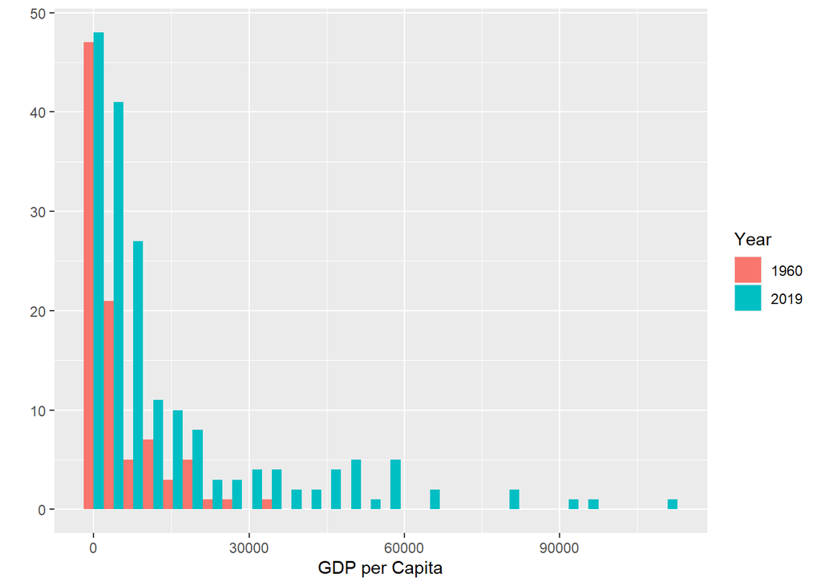

```r
GDP_histo <- gapminder %>%
  filter(time %in% c(1960, 2019) & !is.na(GDP_PC))

ggplot(GDP_histo, aes(x = GDP_PC)) +
  geom_histogram(aes(fill = factor(time)), position = 'dodge') +
  labs(x = "GDP per Capita", y = "", fill = "Year")
```

6. Above is a histogram displaying the GDP/capita for 1960 and 2019

```r
us_ranking <- GDP_histo %>%
  filter(name != "", !is.na(time), !is.na(lifeExpectancy)) %>%
  group_by(time) %>%
  mutate(ranking=rank(desc(lifeExpectancy), na.last=TRUE)) %>%
  filter(name=="United States of America") %>%
  select(time, ranking)
us_ranking
```

```
## # A tibble: 2 × 2
## # Groups:   time [2]
##    time ranking
##   <dbl>   <dbl>
## 1  1960      10
## 2  2019      40
```

7. In 1960, US was ranked 10th, and in 2019 it was ranked 40th.

```r
GDP_histo %>%
  filter(name != "", !is.na(time), !is.na(lifeExpectancy)) %>%
  group_by(time) %>%
  summarize(num_country=n_distinct(name)) %>%
  summarize(time,
            relative=us_ranking$ranking/num_country)
```

```
## # A tibble: 2 × 2
##    time relative
##   <dbl>    <dbl>
## 1  1960    0.114
## 2  2019    0.225
```

8. The relative rank of the US in 1960 was 0.1136364 and 0.2247191 in 2019.

This assignment took around 6 hours